# Predicting Exercise quality based on wearables devices data

smjb

September 22, 2015

# Introduction

Devices such as Jawbone Up, Nike FuelBand, and Fitbit is used to collect a large amount of data about personal activity. These type of devices are part of the quantified self movement - a group of enthusiasts who take measurements about themselves regularly to improve their health, to find patterns in their behavior, or because they are tech geeks. One thing that people regularly do is quantify how much of a particular activity they do, but they rarely quantify how well they do it.

Researchers from Department of Informatics, Pontifical Catholic University of Rio de Janeiro have conducted an experiment where they invite 6 participants to perform barbell lifts correctly and incorrectly in 5 different ways. They collect data from accelerometers on the belt, forearm, arm, and dumbell of these participants. More information is available from the [website here](http://groupware.les.inf.puc-rio.br/har) (see the section on the Weight Lifting Exercise Dataset).

The data are downloaded in two parts : the [training](https://d396qusza40orc.cloudfront.net/predmachlearn/pml-training.csv) set and the [test](https://d396qusza40orc.cloudfront.net/predmachlearn/pml-testing.csv) set.

# Objective and Methodology

The goal of this report is to show the prediction of the manner in which they did the exercise. This is the “classe” variable in the training set.

The data is first cleaned and only the relevant measurement columns without missing values will be selected to be used in the prediction.

The training source dataset is first split into two with 65:35 ratio. 65% is for model training, while the 35% is for model validation. We also use 3 different prediction methods (Trees, Random Forest, and Boosting ) to compare the accuracy using the model validation dataset. The source test dataset is finally used to validate the prediction model made.

Note that the memory requirement is extremely high if we use all the columns in the *train* function. We conciously only used columns that are fully numeric without missing values.

# original instruction

*You should create a report describing how you built your model, how you used cross validation, what you think the expected out of sample error is, and why you made the choices you did. You will also use your prediction model to predict 20 different test cases.*

# Data Cleansing

## Loading the source dataset

```r
## Load data, download if not yet available.

fbigdata <- "pml-training.csv"
fverify <- "pml-testing.csv"

db_dl<-F
if(!file.exists(fbigdata)) {
    download.file(trainUrl, fbigdata, method="auto")
    db_dl<-T
}

ver_dl<-F
if(!file.exists(fverify)) {
    download.file(verifyUrl, fverify, method="auto")
    ver_dl<-T
}

dDB <- read.csv(fbigdata)
DB_dim <- dim(dDB)
dVerify <- read.csv(fverify)
verify_dim <- dim(dVerify)
```

The training data was read from local cache.. Training file dimension is 19622x160.

There are only 406 complete cases found in the training data.

The validation data was read from local cache.. Training file dimension is 20x160.

## Cleaning and selecting the measurement

We extract the names of each column and identify the columns that are actually measurements. We also identify columns that have missing values and those that don’t. Finally we only use measurement columns that have no missing values and where the values are numeric.

```r
cnames <- data.frame(coln=colnames(dDB))
cnames <- mutate(cnames, idx = as.numeric(rownames(cnames)),
                        measurement = !grepl("^X|timestamp|window|user|classe", coln))

v<-data.frame() # temporary variable
for (i  in 1:DB_dim[2]) {
    r <- data.frame(idx=i, coln=names(dDB)[i], isna = length(which(is.na(dDB[,i]))))
    v<-rbind(v,r)
}

v <- mutate(v, extra_info = grepl("^X|timestamp|window", coln),
                measurement = !grepl("^X|timestamp|window|user|classe", coln))

#Create subset data where only measurement columns without missing values are selected
complete_measurement_cols <- filter(v, extra_info==FALSE, isna==0)
rm("v") # remove temporary
rm("r") # remove temporary

dDB_subset <- select(dDB, complete_measurement_cols$idx)

#attempt to use numerical fields only, due to memory limitation
classetemp <- dDB_subset$classe

#Create smaller subset data where only numerical measurement columns without missing values are selected
dDB_num_subset_idx <- sapply(dDB_subset, is.numeric)

dDB_num_subset <- cbind(classe=classetemp, dDB_subset[,dDB_num_subset_idx])
dim_dDB_num_subset <- dim(dDB_num_subset)

## pseudo cleaning complete ...
```

After the cleaning and subsetting process, the cleaned training data dimension is 19622 rows and 53 columns.

## Exploratory visualization

The experiment objective is to see whether we can predict the quality of the exercise lifting a dumbbell. The researchers did experiments on 6 test subject, each of them has 4 sensors attached : Arm, Forearm, Belt and Dumbbell. Each of the test subject will then lift the dumbbell in 5 different ways labeled [`A`, `B`, `C`, `D`, `E`], `A` being the correct way while the others are not.

The Roll,Pitch & Yaw plots in Appendix shows the relationship between the Roll, Pitch & Yaw of each sensors grouped by the exercise Class and the test subject. We observe that the pattern are plausibly different between the classes but the pattern is also highly dependant on the test subject. The prediction model for the exercise class may be unsuitable to predict another subject exercise quality.

## Predicting

### Preparation

We separate the cleaned dataset into a 65:35 training and test subsets.

```r
set.seed(13927)
dDB_num_subset_part <- createDataPartition(dDB_num_subset$classe, p=0.65, list=F)
dDB_num_subset_train <- dDB_num_subset[dDB_num_subset_part, ]
dDB_num_subset_test <- dDB_num_subset[-dDB_num_subset_part, ]
```

We use 5-fold cross validation when we apply each of the algorithm

```r
ctrl_cv <- trainControl(method="cv", 5)
```

### Recursive partitioning Algorithm

We train the Recursive Partitioning Algoritm with default values except we set the cross validation at 5-folds.

```r
dDB_cc_model_rpart <- train(classe ~ ., data=dDB_num_subset_train, method="rpart", trControl=ctrl_cv)
```

```r
modelpred_rpart <- predict(dDB_cc_model_rpart, dDB_num_subset_test)
cm_rpart <- confusionMatrix(dDB_num_subset_test$classe, modelpred_rpart)
accuracy_rpart <- postResample(modelpred_rpart, dDB_num_subset_test$classe)
```

```
## n= 12757
##
## node), split, n, loss, yval, (yprob)
##       * denotes terminal node
##
##  1) root 12757 9130 A (0.28 0.19 0.17 0.16 0.18)
##    2) roll_belt< 130.5 11689 8070 A (0.31 0.21 0.19 0.18 0.11)
##      4) pitch_forearm< -33.95 1010    3 A (1 0.003 0 0 0) *
##      5) pitch_forearm>=-33.95 10679 8067 A (0.24 0.23 0.21 0.2 0.12)
##       10) magnet_dumbbell_y< 436.5 9015 6462 A (0.28 0.18 0.24 0.19 0.11)
##         20) roll_forearm< 122.5 5670 3374 A (0.4 0.18 0.18 0.17 0.064) *
##         21) roll_forearm>=122.5 3345 2224 C (0.077 0.18 0.34 0.23 0.18) *
##       11) magnet_dumbbell_y>=436.5 1664  827 B (0.035 0.5 0.042 0.22 0.2) *
##    3) roll_belt>=130.5 1068    8 E (0.0075 0 0 0 0.99) *
```

Confusion Matrix for Recursive Partitioning Algorithm

|  | A | B | C | D | E |
| --- | --- | --- | --- | --- | --- |
| A | 1761 | 36 | 150 | 0 | 6 |
| B | 527 | 465 | 336 | 0 | 0 |
| C | 551 | 39 | 607 | 0 | 0 |
| D | 475 | 207 | 443 | 0 | 0 |
| E | 157 | 170 | 364 | 0 | 571 |

Statistics by Class for Recursive Partitioning Algorithm

|  | Sensitivity | Specificity | Pos Pred Value | Neg Pred Value | Prevalence | Detection Rate | Detection Prevalence | Balanced Accuracy |
| --- | --- | --- | --- | --- | --- | --- | --- | --- |
| Class: A | 0.5073 | 0.9434 | 0.9017 | 0.6519 | 0.5056 | 0.2565 | 0.2845 | 0.7254 |
| Class: B | 0.5071 | 0.8549 | 0.3502 | 0.9184 | 0.1336 | 0.0677 | 0.1934 | 0.6810 |
| Class: C | 0.3195 | 0.8812 | 0.5071 | 0.7719 | 0.2768 | 0.0884 | 0.1744 | 0.6003 |
| Class: D | NA | 0.8361 | NA | NA | 0.0000 | 0.0000 | 0.1639 | NA |
| Class: E | 0.9896 | 0.8901 | 0.4525 | 0.9989 | 0.0840 | 0.0832 | 0.1838 | 0.9399 |

From the Confusion Matrix, we see that the algorithm did not manage to distinguish class `D` and there is no Predictive Value for `D` at all. Furthermore, False positive for class `E` the lowest among all. Due to the pecularity that it does not suggest `D` and heavily favorise `A`, `B` and `C` , this suggests that the algorithm needs more tuning to be more effective.

The accuracy of this algoritm is low at 49.585% and the out of sample error is 50.415%. .

### Random Forest Algorithm

We use Random Forest Algoritm to model the dataset.

```r
dDB_cc_model_rf <- train(classe ~ ., data=dDB_num_subset_train, method="rf", trControl=ctrl_cv, ntree=250)
```

```r
modelpred_rf <- predict(dDB_cc_model_rf, dDB_num_subset_test)
cm_rf<-confusionMatrix(dDB_num_subset_test$classe, modelpred_rf)
accuracy_rf <- postResample(modelpred_rf, dDB_num_subset_test$classe)
```

```
##
## Call:
##  randomForest(x = x, y = y, ntree = 250, mtry = param$mtry)
##                Type of random forest: classification
##                      Number of trees: 250
## No. of variables tried at each split: 27
##
##         OOB estimate of  error rate: 0.74%
## Confusion matrix:
##      A    B    C    D    E class.error
## A 3619    6    1    0    1 0.002205680
## B   18 2443    8    0    0 0.010530579
## C    0   11 2206    8    0 0.008539326
## D    1    0   26 2060    4 0.014825442
## E    0    1    5    5 2334 0.004690832
```

This method seems to fit the test data very well. The accuracy of this algoritm is very high at 99.111% and the out of sample error is 0.889%.

Confusion Matrix for Random Forest Algorithm

|  | A | B | C | D | E |
| --- | --- | --- | --- | --- | --- |
| A | 1953 | 0 | 0 | 0 | 0 |
| B | 17 | 1309 | 2 | 0 | 0 |
| C | 0 | 3 | 1188 | 6 | 0 |
| D | 0 | 1 | 19 | 1102 | 3 |
| E | 0 | 1 | 2 | 7 | 1252 |

Statistics by Class for Random Forest Algorithm

|  | Sensitivity | Specificity | Pos Pred Value | Neg Pred Value | Prevalence | Detection Rate | Detection Prevalence | Balanced Accuracy |
| --- | --- | --- | --- | --- | --- | --- | --- | --- |
| Class: A | 0.9914 | 1.0000 | 1.0000 | 0.9965 | 0.2870 | 0.2845 | 0.2845 | 0.9957 |
| Class: B | 0.9962 | 0.9966 | 0.9857 | 0.9991 | 0.1914 | 0.1907 | 0.1934 | 0.9964 |
| Class: C | 0.9810 | 0.9984 | 0.9925 | 0.9959 | 0.1764 | 0.1731 | 0.1744 | 0.9897 |
| Class: D | 0.9883 | 0.9960 | 0.9796 | 0.9977 | 0.1624 | 0.1605 | 0.1639 | 0.9922 |
| Class: E | 0.9976 | 0.9982 | 0.9921 | 0.9995 | 0.1828 | 0.1824 | 0.1838 | 0.9979 |

### Generalized Boosted Regression Algorithm

We use Generalized Boosted Regression Algorithm to model the dataset.

```r
dDB_cc_model_gbm <- train(classe ~ ., data=dDB_num_subset_train, method="gbm", trControl=ctrl_cv)
```

```
## A gradient boosted model with multinomial loss function.
## 150 iterations were performed.
## There were 52 predictors of which 46 had non-zero influence.
```

```r
modelpred_gbm <- predict(dDB_cc_model_gbm, dDB_num_subset_test)
cm_gbm<-confusionMatrix(dDB_num_subset_test$classe, modelpred_gbm)
accuracy_gbm <- postResample(modelpred_gbm, dDB_num_subset_test$classe)
```

Confusion Matrix for Generalized Boosted Regression Algorithm

|  | A | B | C | D | E |
| --- | --- | --- | --- | --- | --- |
| A | 1927 | 15 | 4 | 3 | 4 |
| B | 48 | 1241 | 34 | 5 | 0 |
| C | 0 | 30 | 1144 | 17 | 6 |
| D | 0 | 3 | 39 | 1069 | 14 |
| E | 1 | 14 | 9 | 27 | 1211 |

Statistics by Class for Generalized Boosted Regression Algorithm

|  | Sensitivity | Specificity | Pos Pred Value | Neg Pred Value | Prevalence | Detection Rate | Detection Prevalence | Balanced Accuracy |
| --- | --- | --- | --- | --- | --- | --- | --- | --- |
| Class: A | 0.9752 | 0.9947 | 0.9867 | 0.9900 | 0.2878 | 0.2807 | 0.2845 | 0.9849 |
| Class: B | 0.9524 | 0.9844 | 0.9345 | 0.9888 | 0.1898 | 0.1808 | 0.1934 | 0.9684 |
| Class: C | 0.9301 | 0.9906 | 0.9557 | 0.9848 | 0.1792 | 0.1666 | 0.1744 | 0.9603 |
| Class: D | 0.9536 | 0.9903 | 0.9502 | 0.9909 | 0.1633 | 0.1557 | 0.1639 | 0.9719 |
| Class: E | 0.9806 | 0.9909 | 0.9596 | 0.9957 | 0.1799 | 0.1764 | 0.1838 | 0.9858 |

This model is also performing well but the time needed is much higher than Random Forest. The accuracy of this algoritm is at 96.023% and the out of sample error is 3.977%.

### Comparison

Overall statistics Comparison

| Algorithm | Accuracy | Kappa | AccuracyLower | AccuracyUpper | AccuracyNull | AccuracyPValue | McnemarPValue |
| --- | --- | --- | --- | --- | --- | --- | --- |
| rpart | 0.4958 | 0.3424 | 0.484 | 0.5077 | 0.5056 | 0.9484 | NaN |
| rf | 0.9911 | 0.9888 | 0.9886 | 0.9932 | 0.287 | 0 | NaN |
| gbm | 0.9602 | 0.9497 | 0.9553 | 0.9647 | 0.2878 | 0 | 0 |

From the table above, we see that Random Forest Algorithm performed very well followed by Generalized Boosted Regression Algorithm. Recursive Partitioning Algorithm may need some further tuning to be at par with the other two.

# Testing against Validation Dataset

We use Random Forest Algorithm to predict the validation dataset.

```r
#Execute the column selection for the Validation Dataset
dVerify_subset <- select(dVerify, complete_measurement_cols$idx,-problem_id)
dVerify_num_subset_idx <- sapply(dVerify_subset, is.numeric)
dVerify_num_subset <- dVerify_subset[,dVerify_num_subset_idx]
dim_dVerify_num_subset <- dim(dVerify_num_subset)
```

```r
valpred_rf <- predict(dDB_cc_model_rf, dVerify_num_subset)
```

The predicted class for each problem_id is

```r
valpred_rf
```

```
##  [1] B A B A A E D B A A B C B A E E A B B B
## Levels: A B C D E
```

# Appendix

## Roll, Pitch & Yaw plots

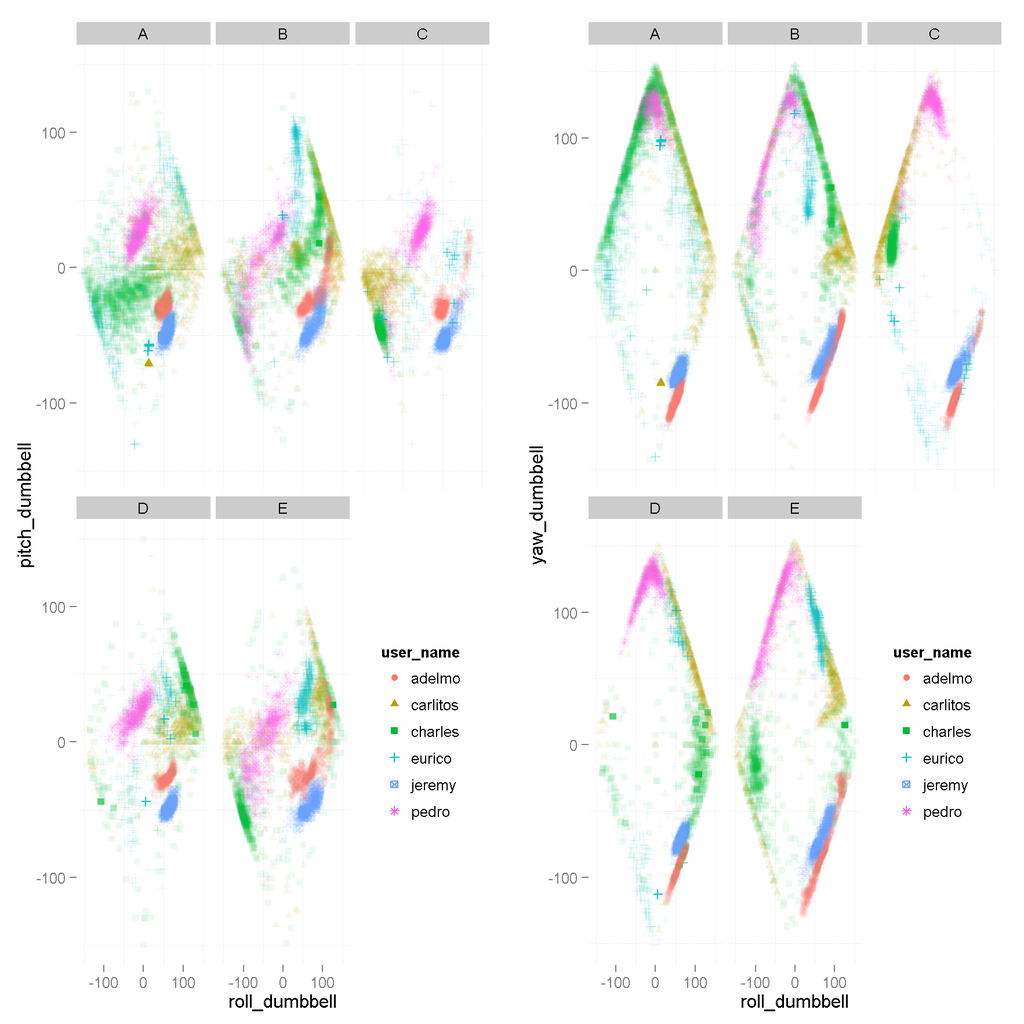

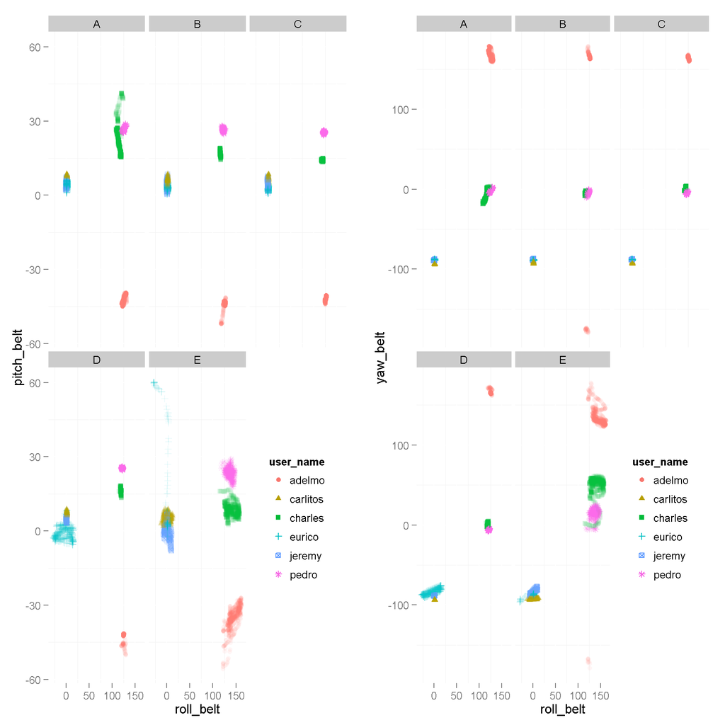

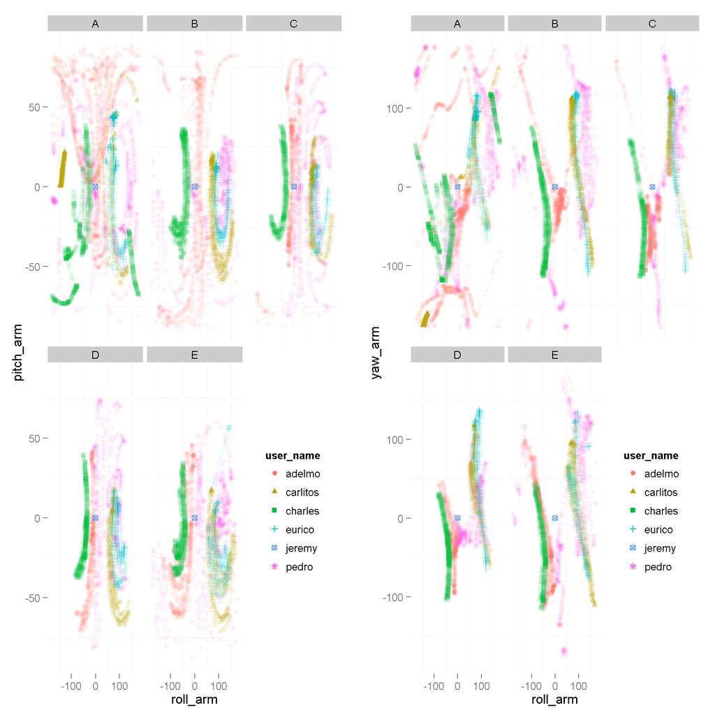

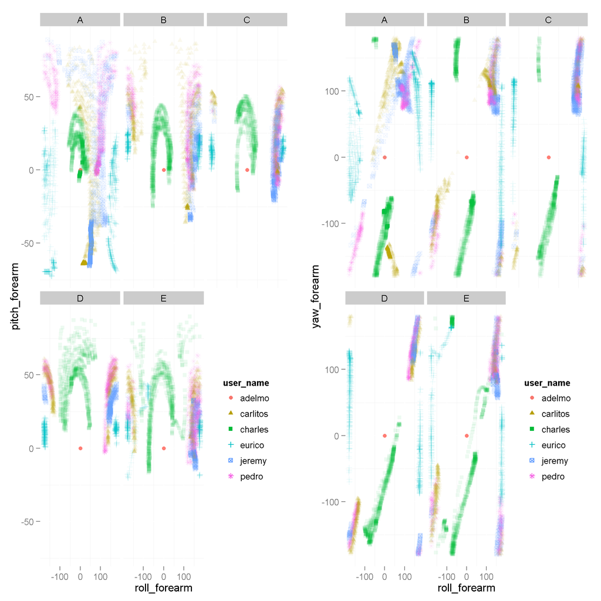